# Resolucion

luis gonzalo

2023-10-22

Problema 1

Se pide tomar la decision optima de la siguiente tabla de decision con los criterios estudiados:

```
e1 e2  e3  e4
```

d1 -13 9 -15 -12 d2 0 -8 6 -1 d3 1 0 10 -12

Cargamos el archivo con las funciones y guardamos los datos

```r
source("teoriadecision_funciones_incertidumbre.R")
tabla = c(-13,9,-15,-12,0,-8,6,-1,1,0,10,-12)
tabladecision1 = crea.tablaX(tabla,3,4)
```

Primero: Caso favorable

Criterio de Wald

```r
criterio.Wald(tabladecision1, favorable = T)$AlternativaOptima
```

```
## d2
##  2
```

Se elige la alternativa d2

Criterio Optimista

```r
criterio.Optimista(tabladecision1, favorable = T)$AlternativaOptima
```

```
## d3
##  3
```

Se elige la alternativa d3

```r
criterio.Hurwicz(tabladecision1, favorable = T, alfa = 0.5)$AlternativaOptima
```

```
## d2 d3
##  2  3
```

Son igual de optimas las alternativas d2 que d3 veamos que ocurre para distintos alfas

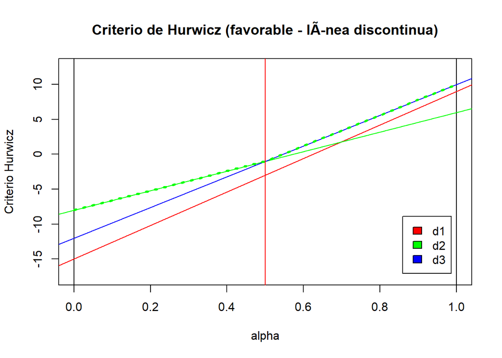

```
## $AltOptimas
## [1] 2 3
##
## $PuntosDeCorte
## [1] 0.5
##
## $IntervalosAlfa
##      Intervalo     Alternativa
## [1,] "( 0 , 0.5 )" "2"
## [2,] "( 0.5 , 1 )" "3"
```

```r
dibuja.criterio.Hurwicz_Intervalos(tabladecision1)
```

En la grafica se observa que para valores de alfa menores que 0.5 se elige la alternativa d2, para valores mayores que 0.5 se elige la alternativa d3

Criterio de Savage

```r
criterio.Savage(tabladecision1, favorable = T)$AlternativaOptima
```

```
## d3
##  3
```

Se elige la alternativa d3

Criterio de Laplace

```r
criterio.Laplace(tabladecision1, favorable = T)$AlternativaOptima
```

```
## d3
##  3
```

Se elige la alternativa d3

Criterio del punto ideal

```r
criterio.PuntoIdeal(tabladecision1, favorable = T)$AlternativaOptima
```

```
## d3
##  3
```

Se elige la alternativa d3

Segundo: Caso desfavorable

Criterio de Wald

```r
criterio.Wald(tabladecision1, favorable = F)$AlternativaOptima
```

```
## d2
##  2
```

Se elige la alternativa d2

Criterio Optimista

```r
criterio.Optimista(tabladecision1, favorable = F)$AlternativaOptima
```

```
## d1
##  1
```

Se elige la alternativa d1

```r
criterio.Hurwicz(tabladecision1, favorable = F, alfa = 0.5)$AlternativaOptima
```

```
## d1
##  1
```

Se elige la alternativa d1

Veamos que ocurre para distintos alfas

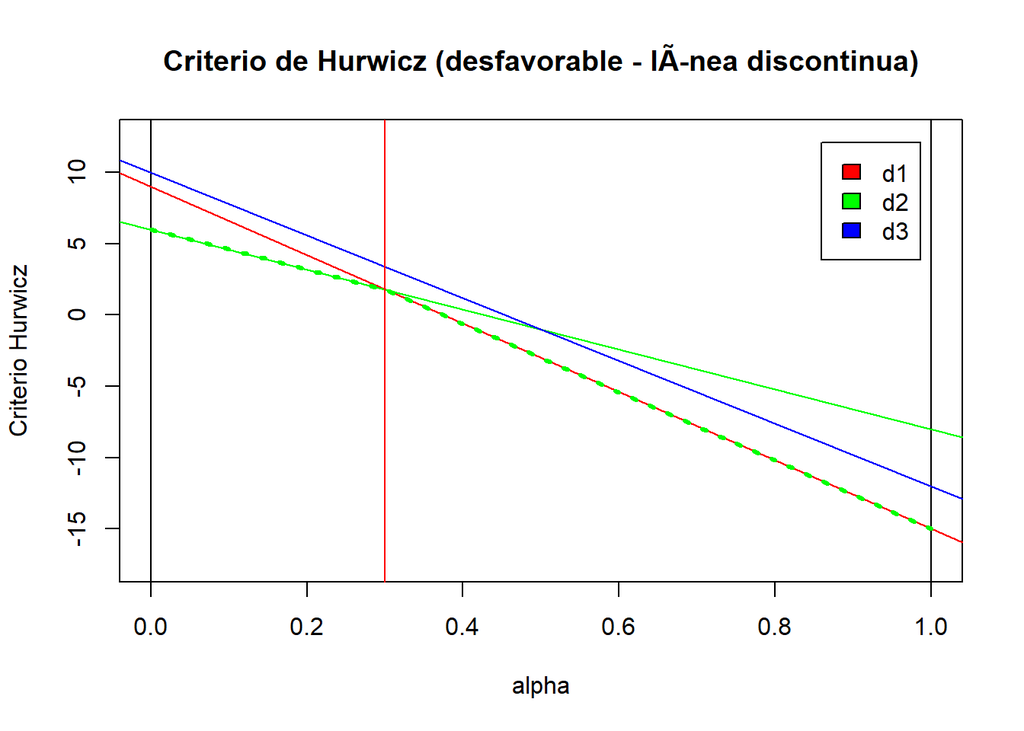

```
## $AltOptimas
## [1] 2 1
##
## $PuntosDeCorte
## [1] 0.3
##
## $IntervalosAlfa
##      Intervalo     Alternativa
## [1,] "( 0 , 0.3 )" "2"
## [2,] "( 0.3 , 1 )" "1"
```

```r
dibuja.criterio.Hurwicz_Intervalos(tabladecision1, favorable = F)
```

En la grafica se observa que para valores de alfa menores que 0.3 se elige la alternativa d2, para valores mayores que 0.3 se elige la alternativa d1

Criterio de Savage

```r
criterio.Savage(tabladecision1, favorable = F)$AlternativaOptima
```

```
## d1
##  1
```

Se elige la alternativa d1

Criterio de Laplace

```r
criterio.Laplace(tabladecision1, favorable = F)$AlternativaOptima
```

```
## d1
##  1
```

Se elige la alternativa d1

Criterio del punto ideal

```r
criterio.PuntoIdeal(tabladecision1, favorable = F)$AlternativaOptima
```

```
## d1
##  1
```

Se elige la alternativa d1

Problema 2

Jose Luis quiere abrir un local en Sevilla y tiene tres opciones: - La primera se encuentra en pleno centro de la ciudad con unas estimaciones de beneficios de 46,5 mil euros al año en el mejor de los casos 30 mil en un caso intermedio y con perdidas de 26 mil en el peor de los casos. - La segunda se encuentra cerca del centro, con unas estimaciones de beneficios de 27 mil euros al año en el mejor de los casos, 19.5 mil euros en un caso intermedio y con perdidas de 14 mil euros en el peor de los casos - La tercera es abrir un pequeño local en un barrio que tiene unas estimaciones de beneficios de 18 mil euros al año en el mejor de los casos, 13 mil euros en un caso intermedio y 2,5 mil euros de perdidas en el peor de los caso. Tambien se contempla la opcion de no abrir ningun local. ¿Cual es la mejor decision?

Planteamiento - Las decisiones se presentan como beneficios. Caso favorable

Alternativas

- d1: Abrir un local en el centro
- d2: Abrir un local cerca del centro
- d3: Abrir el pequeño local en el barrio
- d4: No abrir ningun local

Estados de la naturaleza - e1: Mercado favorable - e2: Mercado neutro - e3: Mercado desfavorable

```r
tabla = c(46.5,30,-26,27,19.5,-14,18,13,-2.5,0,0,0)
tabladecision2 = crea.tablaX(tabla,4,3)
```

La tabla es la siguiente e1 e2 e3 d1 46.5 30.0 -26.0 d2 27.0 19.5 -14.0 d3 18.0 13.0 -2.5 d4 0.0 0.0 0.0

```r
criterio.Todos(tabladecision2, alfa=0.5)
```

```
##                   e1   e2    e3  Wald Optimista Hurwicz Savage Laplace
## d1              46.5 30.0 -26.0 -26.0      46.5   10.25   26.0   16.83
## d2              27.0 19.5 -14.0 -14.0      27.0    6.50   19.5   10.83
## d3              18.0 13.0  -2.5  -2.5      18.0    7.75   28.5    9.50
## d4               0.0  0.0   0.0   0.0       0.0    0.00   46.5    0.00
## iAlt.Opt (fav.)   --   --    --    d4        d1      d1     d2      d1
##                 Punto Ideal
## d1                    26.00
## d2                    26.20
## d3                    33.28
## d4                    55.34
## iAlt.Opt (fav.)          d1
```

En el caso pesimista, lo mejor es no arriesgarse (alternativa d4) Bajo el criterio optimista, se abre el local en el centro (alternativa d1) Bajo el criterio de Hurwicz, y con un indice de optimismo del 0.5, se eligiria abrir el local en el centro (alternativa d1) Bajo el criterio de Savage, se elige abrir el local cerca del centro (alternativa d2) Bajo el criterio de Laplace, se elige abrir el local en el centro (alternativa d1) Bajo el criterio del punto ideal y con la norma euclidea, se elige abrir el local en el centro (alternativa d1)

Conclusion: Mi decision final seria abrir en el centro, ya que bajo la mayoria de criterios expuestos, se tiene dicha decision.